# Drift Diffusion Model Results

Aviva Blonder

July 25, 2016

Reading in and minimal formatting of reaction time and accuracy data

```r
df <- read.csv("data/3_final_merged_data/speed-acc-ss-df.csv",
               check.names=F, stringsAsFactors=F)

df <- df %>%
  mutate(stimuli = ifelse(stimuli == "V1" | stimuli == "V2", "ASL",
                          ifelse(stimuli == "Trio", "Object",
                                 ifelse(stimuli == "Bull", "Bullseye",
                                        stimuli))),
         stimuli = factor(stimuli, levels = c("ASL", "Face", "Object", "Bullseye"))) %>%
  # just analyzing child data, only from participants who exhibited a shift
  filter(age_code == "child", trial_type != "no_shift")
```

# Off-the-shelf Drift Diffusion Model

Workflow taken from Nordmeyer et al. (2016). We estimate parameters separately for each participant and then aggregate across participants to get means & confidence intervals on the parameters.

The parameters of the drift drift diffusion model are:

- $\alpha$ = boundary separation: speed-accuracy tradeoff (higher values mean higher accuracy)
- $\beta$ = initial bias
- $\delta$ = drift rate: speed of information processing (close to zero means ambiguous information)
- $\tau$ = nondecision time: motor response time

## DDM function

Functiont that formats data and fits the DDM to each participant using Rwiener function

```r
ddm <- function(data, RTcutoff = .1){
# columns need to be named "q" for RT and "resp" for response

  d <- data %>%
    filter(is.na(RT_sec) == F, RT_sec > RTcutoff) %>%
    select(Sub.Num, stimuli, RT_sec, correct, hearing_status_participant,
           Months) %>%
    mutate(resp = factor(correct),
           resp = plyr::revalue(resp, c("0" = "lower", "1" = "upper")),
           resp = relevel(resp, "upper")) %>%
    rename(q = RT_sec)

  sub.pars <- data.frame(Separation = numeric(),
                       Non.Decision = numeric(),
                       Bias = numeric(),
                       Drift = numeric(),
                       Condition = character(),
                       Hearing.Status = character(),
                       Age.Months = character(),
                       Sub.Num = character(),
                       stringsAsFactors = F)

  #because RWiener is finicky:
  d$resp <- as.character(d$resp)


  # Fitting the Drift Diffusion Model for each participant
  conditions <- unique(as.character(d$stimuli))
  subs <- unique(as.character(d$Sub.Num))
  trialcount <- group_by(d, Sub.Num) %>%
      summarize(num = n())

  for (j in 1:length(subs)) {
    sid <- as.character(subs[j])
    dat <- as.data.frame(filter(d, Sub.Num == sid))
    condition_type <- unique(as.character(dat$stimuli))
    hearing_status <- unique(as.character(dat$hearing_status_participant))
    age <- unique(as.character(dat$Months))
    # fit ddm for each participant
    opt <- optim(c(1, .1, .1, 1), wiener_deviance,
                 dat=select(dat, c(q, resp)), method="Nelder-Mead")
    pars <- c(opt$par, condition_type, hearing_status, age, sid)
    sub.pars[j,] <- pars
  }


  # cleans up parameters
  sub.pars$Separation <- as.numeric(sub.pars$Separation)
  sub.pars$Non.Decision <- as.numeric(sub.pars$Non.Decision)
  sub.pars$Bias <- as.numeric(sub.pars$Bias)
  sub.pars$Drift <- as.numeric(sub.pars$Drift)
  sub.pars$Age.Months <- as.numeric(sub.pars$Age.Months)

  # removes outliers
  sub.pars <- sub.pars %>%
    group_by(Condition) %>%
    filter(Separation < mean(Separation) + 3 * sd(Separation),
           Separation > mean(Separation) - 3 * sd(Separation)) %>%
    filter(Non.Decision < mean(Non.Decision) + 3 * sd(Non.Decision),
           Non.Decision > mean(Non.Decision) - 3 * sd(Non.Decision)) %>%
    filter(Bias < mean(Bias) + 3 * sd(Bias),
           Bias > mean(Bias) - 3 * sd(Bias)) %>%
    filter(Drift < mean(Drift) + 3 * sd(Drift),
           Drift > mean(Drift) - 3 * sd(Drift)) %>%
    ungroup() %>%
    na.omit()

  sub.pars %<>% gather(Param, Value, Separation:Drift)
  sub.pars <- merge(sub.pars, trialcount, by = "Sub.Num")

  return(sub.pars)
}
```

## DDM Fit to All Child Participants

Distributions of paramters across conditions

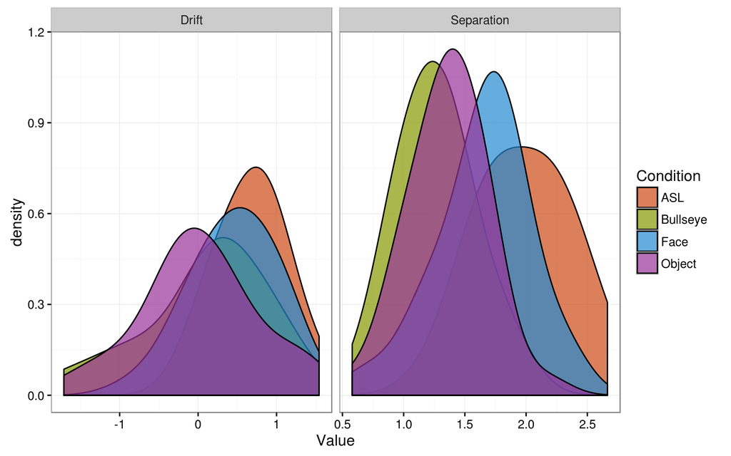

```r
sub.pars <- ddm(df)

ggplot(aes(x = Value, fill = Condition),
       data = filter(sub.pars, Param %in% c("Drift", "Separation"))) +
  geom_density(alpha = 0.7, adjust = 1.5) +
  facet_grid(.~Param, scales = "free") +
  scale_fill_solarized()
```

So far so good:

- Boundary separation tends higher in the ASL condition, indicating an emphasis on accuracy over speed
- Drift seems to be skewed a little higher in the ASL condition, which was not expected
- A surprising number of individuals in the Object and Bullseye conditions have negative drifts, which is a little worrying, since it suggests that they gathered information in favor of the distractor

Means and CIs for parameter values

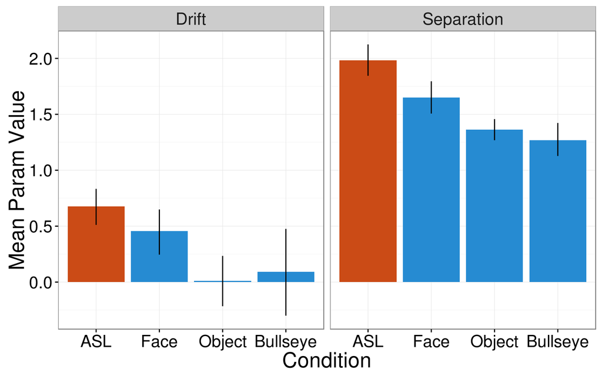

```r
sub.pars.ms <- sub.pars %>%
  group_by(Condition, Param) %>%
  multi_boot_standard(column = "Value", empirical_function = "mean")

sub.pars.ms$Condition <- factor(sub.pars.ms$Condition,
                                levels = c("ASL", "Face", "Object", "Bullseye"))

sub.pars.ms$language_modality <- ifelse(sub.pars.ms$Condition == "ASL", "ASL", "English")

ggplot(aes(x = Condition, y = mean, fill = language_modality),
       data = filter(sub.pars.ms, Param %in% c("Drift", "Separation"))) +
  geom_bar(stat = "identity") +
  geom_linerange(aes(ymin = ci_lower, ymax = ci_upper)) +
  facet_wrap(~Param, ncol = 4) +
  scale_fill_solarized() +
  ylab("Mean Param Value") +
  guides(fill = F) +
  theme(text = element_text(size = 20))
```

Good things first:

- Boundary separation is highest in the ASL condition, again reflecting a prioritization of accuracy over speed, which makes sense - they have to stay fixated on the signer to know where to look, so they should be less likely to look away and more accurate when they do Problems:
- No drift in the Object and Bullseye conditions, suggesting that they’re not gathering any information, which doesn’t make any sense - they’re still hearing the speaker
- Higher drift in the ASL condition, suggesting that they’re gathering more information, even though they’re being exposed the same target word It looks like some of the children, especially the ones being spoken to in English, are looking around randomly before they hear the target word, which isn’t really a decision process. Those trials should be filtered out in a non-arbitrary way.

A boxplot conveys a little more information

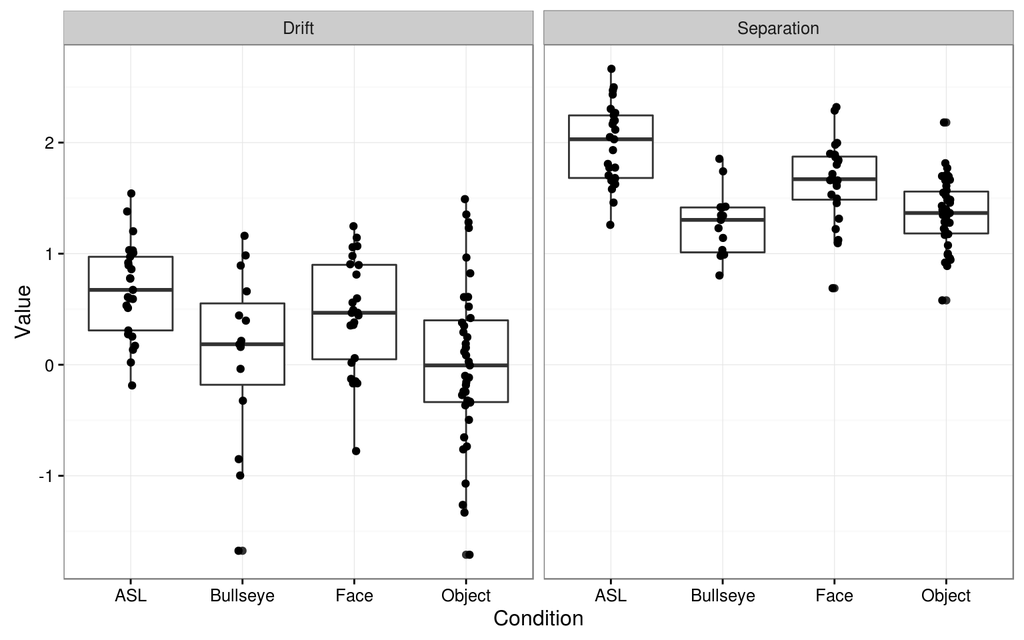

```r
ggplot(aes(x = Condition, y = Value),
       data = filter(sub.pars, Param %in% c("Drift", "Separation"))) +
  geom_boxplot() + geom_jitter(width = .1) +
  facet_wrap(~Param, ncol = 4)
```

For each condition, the boundary separations are fairly evenly distributed and tightly clustered, with a few outliers here and there.

# Exponentially Weighted Moving Average Filter

Vandekerckhove & Tuerlinckx (2007) use an Exponentially Weighted Moving Average (EWMA) to filter reaction time and accuracy data. It is used to remove “fast guesses” that don’t reflect a decision process and therefore can’t be modeled by a Drift Diffusion Model. It goes through a data set ordered by reaction time, calculating the mean for each data point based on the weighted average of the points before it. At each data point, the mean is compared to a calculated threshold to determine if subjects’ accuracy at that point is above chance. The cutoff is the point at which subjects’ responses are reliably above chance and therefore the result of a decision process.

```r
ewma <- function(data){
  # EWMA by hand
  lambda <- .01 # weight of previous parameters
  cs <- .5 # control mean
  sigma <- .5 # control standard deviation
  L <- 1.5 # width of control limits
  results <- data.frame(rt = integer(), cs = integer(), ucl = integer())
  for(row in 1:nrow(data)){
    subj <- data[row, ]
    acc <- as.integer(subj["correct"])
    rt <- as.integer(subj["RT"])
    cs <- lambda*acc + (1-lambda)*cs # weighted average for each rt (row)
    UCL <- .5 + L*sigma*sqrt((lambda/(2 - lambda))*(1-((1-lambda)^(2*row)))) # threshold
    results[row, ] <- c(rt, cs, UCL)
    if(row != 1 && cs < UCL)
      cutoff <- rt
  }

   return(list(cutoff = cutoff, results = results))
}
```

Function used to graph EWMA results

```r
ewma_graph = function(ewma_results){
  results = as.data.frame(ewma_results['results'])
  cutoff = as.numeric(ewma_results['cutoff'])
  plot <- ggplot(results, aes(results.rt)) +
     geom_line(aes(y = results.cs, color = "cs")) +
     geom_line(aes(y = results.ucl, color = "UCL")) +
     geom_vline(aes(xintercept = cutoff), linetype = 2) +
    ylab("Moving Average") + xlab("Reaction Time") +
    theme(text = element_text(size = 20))

  return(plot)
}
```

## Combined EWMA Filter

Running and visualizing the filter

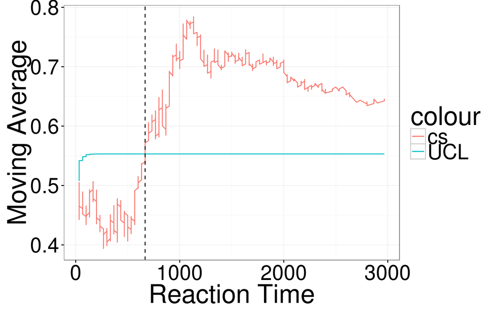

```r
# organize data for use
ewma_data <- arrange(df, RT)
# running the ewma
overallcut <- ewma(ewma_data)

# graph
ewma_graph(overallcut)
```

The dashed line where the weighted average (cs) crosses the threshold (UCL) is the cutoff. All reaction times past that point are considered evidence of a decision process and can be modeled as a diffusion process.

### The resulting paramters:

Parameter density

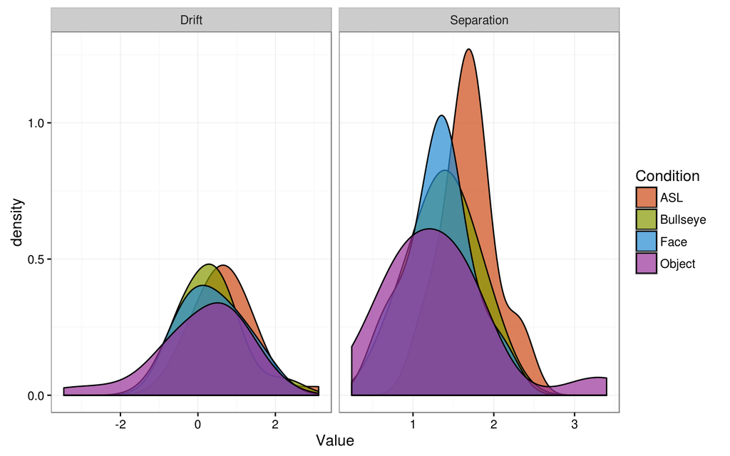

```r
cutoff <- as.numeric(overallcut['cutoff'])/1000
filteredpars_all <- ddm(df, RTcutoff = cutoff)

ggplot(aes(x = Value, fill = Condition),
       data = filter(filteredpars_all, Param %in% c("Drift", "Separation"))) +
  geom_density(alpha = 0.7, adjust = 1.5) +
  facet_grid(.~Param, scales = "free") +
  scale_fill_solarized()
```

Boxplot

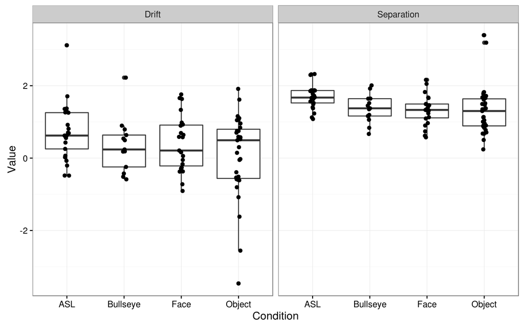

```r
ggplot(aes(x = Condition, y = Value),
       data = filter(filteredpars_all, Param %in% c("Drift", "Separation"))) +
  geom_boxplot() + geom_jitter(width = .1) +
  facet_wrap(~Param, ncol = 4)
```

This tells us pretty much the same thing as before. Mean drift is still higher in the ASL condition and around 0 in the Object and Bullseye conditions, if skewed a little higher. However, now there are more outliers, especially in the Object condiiton. Also, more subjects in the Face condition seem to have lower drift rates, which seems counterintuitive after early guesses, which are supposed to be more likely to be wrong than correct answers, were removed.

## Separate EWMA Filters (by condtion)

Running and visualizing the filter

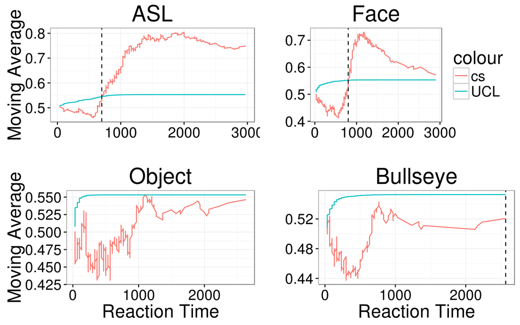

```r
ewma_data <- arrange(df, RT)

# ASL
ASL_ewma <- filter(ewma_data, stimuli == "ASL")
ASLcut <- ewma(ASL_ewma)

# Face
Face_ewma <- filter(ewma_data, stimuli == "Face")
 Facecut <- ewma(Face_ewma)

# Object
 Obj_ewma <- filter(ewma_data, stimuli == "Object")
 Objcut <- ewma(Obj_ewma)

# Bullseye
Bull_ewma <- filter(ewma_data, stimuli == "Bullseye")
Bullcut <- ewma(Bull_ewma)

# combined graph
grid.arrange(ewma_graph(ASLcut) + labs(x = "", title = "ASL") +
               guides(colour = F),
             ewma_graph(Facecut) +
               labs(x = "", y = "", title = "Face"),
             ewma_graph(Objcut) + labs(title = "Object") +
               guides(colour = F),
             ewma_graph(Bullcut) + labs(y = "", title = "Bullseye") +
               guides(colour = F),
             ncol = 2, nrow = 2)
```

Again, the dashed line represents the cutoff past which all responses are considered to be the result of a decision process. In the Object and Bullseye conditions, the weighted average never crosses the threshold, indicating that most of the responses are guesses regardless of reaction time. This suggests that a Drift Diffusion Model is not the best way to represent the data from those conditions.

### The resulting paramters:

Since the EWMA cutoff for the Bullseye and Object conditions would eliminate all trials in those conditions, we will only run Drift Diffusion Models for the ASL and Face conditions based on their separate cutoffs.

Density graph

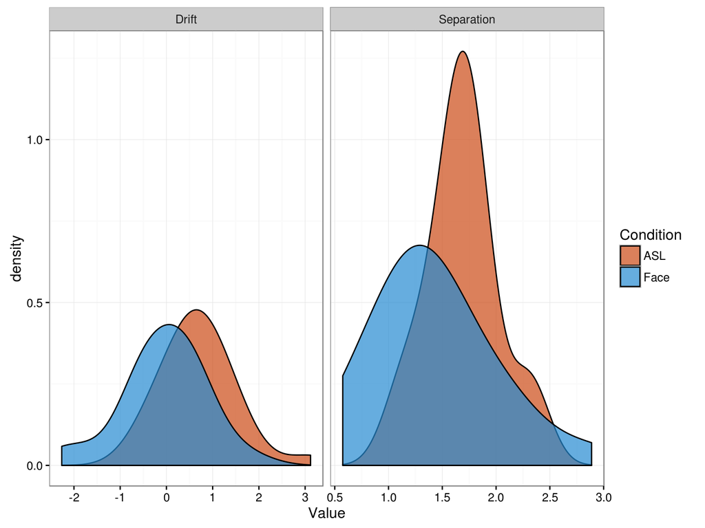

```r
# columns need to be named "q" for RT and "resp" for response
filteredpars_sep <- df %>%
  filter(is.na(RT_sec) == F, (stimuli == "ASL" & RT >= ASLcut['cutoff']) | (stimuli == "Face" & RT >= Facecut['cutoff'])) %>%
  ddm()

ggplot(aes(x = Value, fill = Condition),
       data = filter(filteredpars_sep, Param %in% c("Drift", "Separation"))) +
  geom_density(alpha = 0.7, adjust = 1.5) +
  facet_grid(.~Param, scales = "free") +
  scale_fill_solarized()
```

Boundary separation is still higher in the ASL condition and surprisingly so is the drift. Furthermore, a surprising number of trials in the Face condition have zero or even negative drift, which doesn’t make sense.

Boxplot

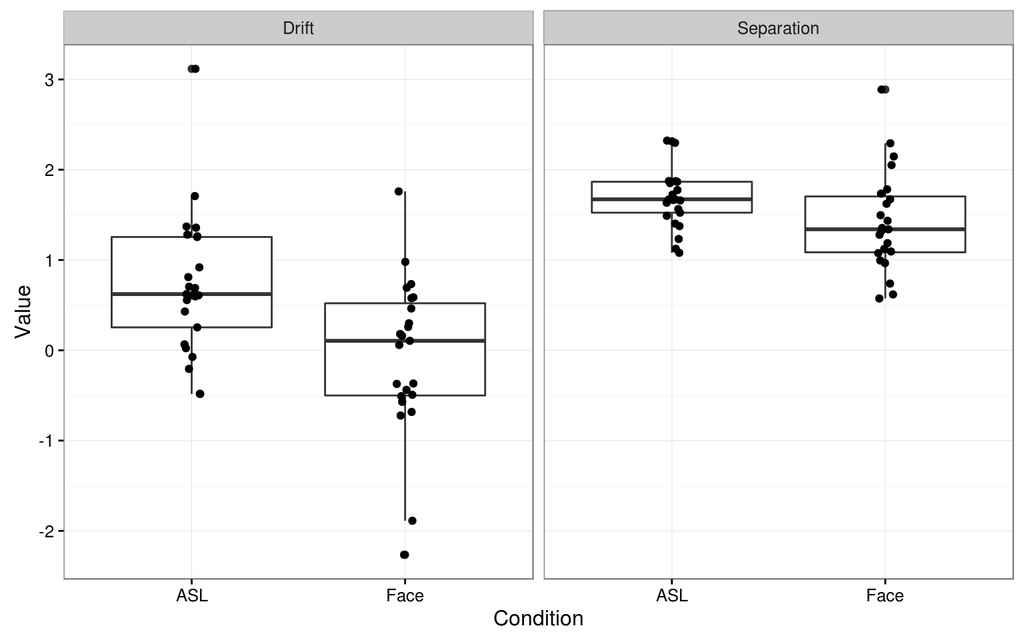

```r
ggplot(aes(x = Condition, y = Value),
       data = filter(filteredpars_sep, Param %in% c("Drift", "Separation"))) +
  geom_boxplot() + geom_jitter(width = .1) +
  facet_wrap(~Param, ncol = 4)
```

Here we can see even more clearly that there’s something strange going on with the drift in the Face condition when we use that cutoff. There are a few outliers, in particular a couple of low ones that are probably dragging down the mean a bit. However, not looking at the outliers, most of the data points are clustered around zero, including a cluster of a few below. The question going forward is why. Drift should go up when fast guesses are removed because only subjects that are actually waiting long enough to gather information and make a decision are included.

The average accuracy of subjects in the Face condition included in the Drift Diffusion Model after the EWMA cutoff is:

```r
filteredavgs_Face <- df %>%
  filter(is.na(RT) == F, stimuli == "Face", RT >= Facecut['cutoff']) %>%
  summarize(avg = mean(correct, na.rm=T))
print(filteredavgs_Face$avg)
```

```
## [1] 0.6813725
```

Not that much lower than the average accuracy of subjects in the ASL condition after the EWMA cutoff:

```r
filteredavgs_ASL <- df %>%
  filter(is.na(RT) == F, stimuli == "ASL", RT >= ASLcut['cutoff']) %>%
  summarize(avg = mean(correct, na.rm=T))
print(filteredavgs_ASL$avg)
```

```
## [1] 0.7723577
```

This indicates that there’s something else going on in fitting parameters to the Drift Diffusion Model for the Face condition. As illustrated by the EWMA graph for the Face condition, mean accuracy drastically decreases for much later reaction times. It may be that some subjects who don’t understand the question or are otherwise distracted are responding late and just guessing when they do. A few individuals could be dragging down the average drift.

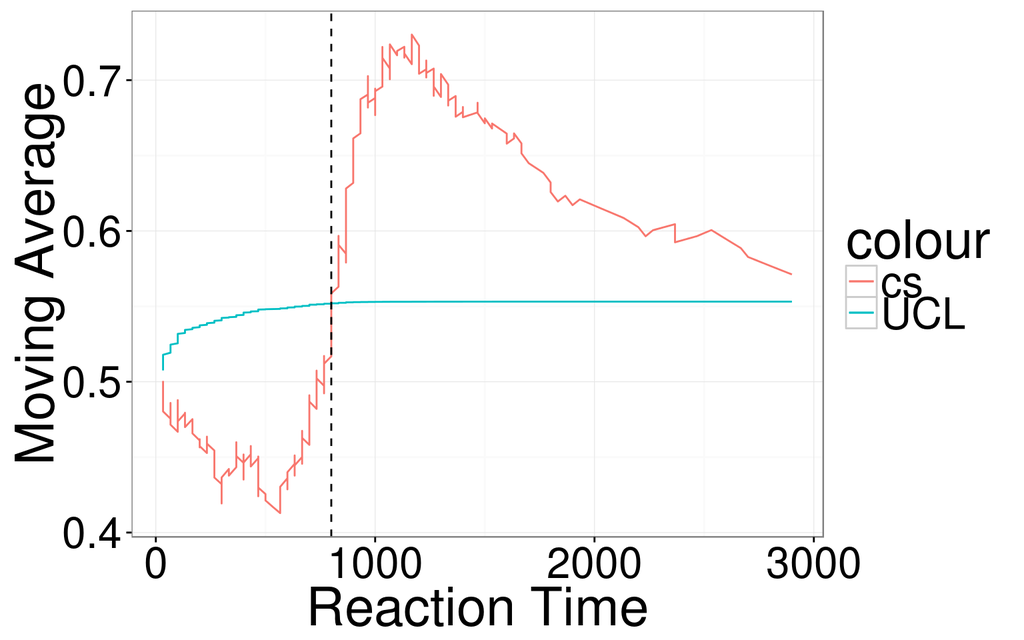

```r
ewma_graph(Facecut)
```

## Alternative cutoffs

The results from the different EWMA cutoffs indicate that mean drift rate varies quite a bit based on where the cutoff is. This function will enable us to run the DDM based on a range of cutoffs and compare the results.

```r
driftcalc <- function(data, splits){
  drift_by_condition <- data.frame()
  for(cutoff in splits){
    thissub.pars <- ddm(data, RTcutoff = cutoff) %>%
      mutate(conditions = as.numeric(cutoff)) %>%
      filter(Param == "Drift") %>%
      rename(Drift = Value)

    drift_by_condition <- rbind(drift_by_condition,
                                select(thissub.pars, Drift, conditions,
                                       Sub.Num, num))
  }
  return(drift_by_condition)
}
```

Calculating drift rates for each subject based on cutoffs every 100 ms from 200 ms to 1000 ms

```r
# generate cutoffs
startcuts <- .2
endcuts <- 1
interval <- .1

Facecut_drift <- driftcalc(filter(df, stimuli == "Face"),
                           seq(startcuts, endcuts, interval))
```

Scatterplot of mean drift for each cutoff point

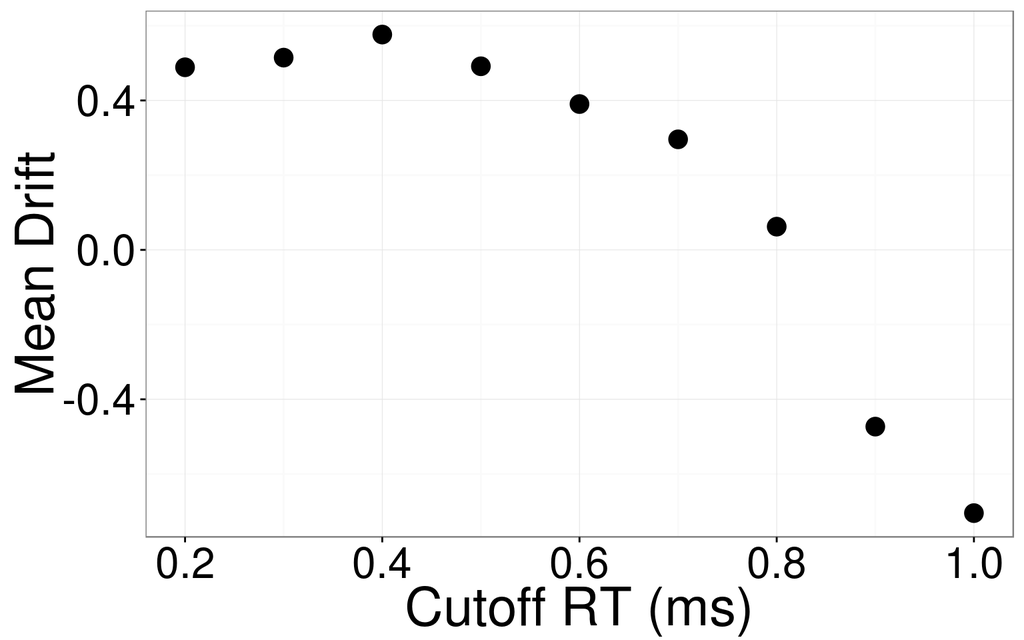

```r
meandrift <- Facecut_drift %>%
  group_by(conditions) %>%
  summarise(avgdrift = mean(Drift))

ggplot(meandrift, aes(y = avgdrift, x = conditions)) +
  geom_point(aes(size = 2.5)) +
  xlab("Cutoff RT (ms)") + ylab("Mean Drift") +
  theme(text = element_text(size=30), legend.position = "none")
```

Boxplots

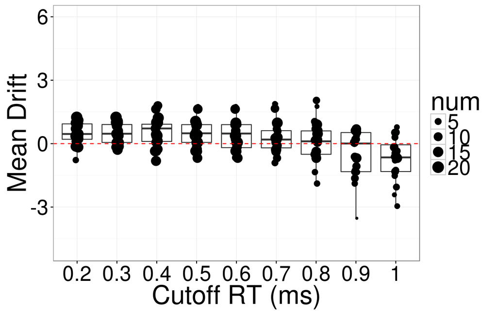

```r
Facecut_drift$conditions <- as.factor(Facecut_drift$conditions)

ggplot(data = Facecut_drift, aes(y = Drift, x = conditions, group = conditions)) +
  geom_boxplot() + geom_jitter(width = .1, aes(size = num)) +
  xlab("Cutoff RT (ms)") + ylab("Mean Drift") +
  theme(text = element_text(size=30)) +
  scale_y_continuous(limit = c(-5, 6)) +
  geom_hline(aes(yintercept = 0), color = "red", linetype = 2)
```

It looks like there are a few subjects whose mean drift rates drop (and a few whose drift rates jump) when their earlier trials are removed. With how drastic the change is in some cases, it looks like there just isn’t enough data once these cuts are made to balance outliers.

We’ve learned what we can from what we have, going forward, it’s time to collect more data.